# How likely is it to be out for 99?

Duncan Golicher

2017-8-4

## Introduction

In the test against South Africa Johnny Bairstow frustratingly ended his innings on 99. Then Joe Root ended his on 49. Making a hundred is a more important milestone than making a fifty. I wondered how the effect of seeing the hundred in sight affects batsmen. Data here.

https://github.com/dgolicher/cricket

## The data

Innings are effectively right censored suvivorship data that could be analysed using Kaplan-Meier curves. However here I’ll just look at completed innings that ended with the batsman out.

```r
knitr::opts_chunk$set(warning = FALSE,message = FALSE,error = TRUE)

d<-read.csv("innings_fixed.csv")
nhundreds<-length(d$Runs[d$Runs>99])
nhundreds
```

```
## [1] 13820
```

```r
d$Date<-as.Date(d$Date)
d<-subset(d, d$Notout!=TRUE)
nnineties<-length(d$Runs[d$Runs>89&d$Runs<100])
nnineties/(nhundreds+nnineties)
```

```
## [1] 0.4350652
```

```r
nnineties
```

```
## [1] 10643
```

```r
nhundreds
```

```
## [1] 13820
```

## Frequency of all innings

A ggplot barplot automatically uses counts of observations if no other information is provided. This can be zoomed to sections when using plotly.

```r
library(ggplot2)
library(plotly)
theme_set(theme_bw())
g0<-ggplot(subset(d,d$Runs<110),aes(x=Runs))
g1<-g0+geom_bar()
ggplotly(g1)
```

[interactive chart not shown]

Notice that the pattern follows a more or less exponential decay. The single most likely score for a batsman to make is zero, as all batsmen start on zero. From that point onwards the batsmen cannot be out on all possible scores, as the scoring does not move forward in singles.

At the beginning of the sequence there is a second spike at four, as there are many combinations of strokes, including scoring a boundary that get a batsman to this point after starting on zero.

```r
g0<-ggplot(subset(d,d$Runs<7),aes(x=Runs))
g1<-g0+geom_bar() + scale_x_discrete(limits=0:6)
ggplotly(g1)
```

[interactive chart not shown]

## Nervous nineties

The frequency pattern in the nineties is interesting. A pure exponential decay would have a constant hazard. However the pattern deviates from this because batsmen have their eye on the target of 100 and adjust their scoring strokes accordingly.

```r
g0<-ggplot(subset(d,d$Runs>89&d$Runs<110),aes(x=Runs))
g1<-g0+geom_bar() + scale_x_discrete(limits=90:110)
ggplotly(g1)
```

[interactive chart not shown]

```r
dd<-data.frame(table(d$Runs))
names(dd)<-c("Runs","Freq")
```

```r
dd<-data.frame(start=-1,end=d$Runs,event=ifelse(d$Notout==TRUE,0,1))
library(survival)
surv_ob<-Surv(dd$start,dd$end,dd$event)
head(surv_ob)
```

```
## [1] (-1,380] (-1,375] (-1,374] (-1,364] (-1,340] (-1,337]
```

```r
km <- survfit(surv_ob ~ 1, data = dd, conf.type = "log-log")
km
```

```
## Call: survfit(formula = surv_ob ~ 1, data = dd, conf.type = "log-log")
##
##    9810 observations deleted due to missingness
##   n.max n.start  events  median 0.95LCL 0.95UCL
##   69763       0   69763      14      14      14
```

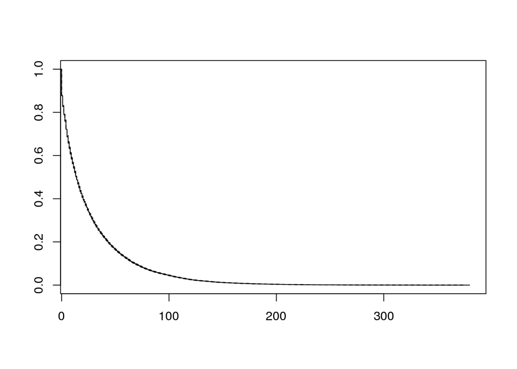

```r
plot(km)
```